# Part 2: Forecast daily values for NEON Forecasting Challenge

# Introduction

In this part, we follow a workflow for forecasting daily values of GCC. As a reminder, GCC is the green chromatic coordinate from a phenocam. The variable we will look at is `gcc_90` which is the 90th percentile of the GCC within a region of interest.

Read more about the NEON Ecological Forecasting Challenge for phenology [here](https://projects.ecoforecast.org/neon4cast-docs/Phenology.html).

In addition to the `tidyverse` package, we will install and load additional packages specific to making a forecast.

- `forecast` package provides methods and tools for forecasting time series. Read more [here](https://pkg.robjhyndman.com/forecast/).
- `scoringRules` package includes functions to evaluate the accuracy of a forecast. Read more [here](https://github.com/FK83/scoringRules).

```r
# install neon4cast if submitting to the NEON Forecasting Challenge
#install.packages("neon4cast")
#library(neon4cast)

#install.packages("scoringRules")
library(scoringRules)

#install.packages("forecast")
library(forecast)

library(tidyverse)
```

## Workflow steps for our forecast:

1. Set a forecast date by defining when it will start. In our case we are selecting a date mid-way through our data set so that we can compare. If submitting to NEON forecasting challenge, set the date as `forecast_date = Sys.Date()` to get a real-time application.
2. Define our model. In this case we will use a linear model as an example.
3. Use model to predict, visualize, and score
4. Optionally, submit to NEON Forecasting challenge

To do this forecast, we assume that Part 1 has been completed, and a CSV file has been saved, named `gcc_neon_join.csv`. If you used a different name, you will want to change the text below.

```r
csv_file = "gcc_neon_join.csv"

neon_join = read.csv(csv_file)

# date when forecast will start
forecast_date = lubridate::as_date("2022-01-01")

# split our data frame neon_join into model values and prediction values
# past values for model
past_model = neon_join %>%
  filter(date < forecast_date) %>%
  filter(variable == "gcc_90") %>%
  rename(gcc_90 = observation)

# future values for prediction
fut_pred = neon_join %>%
  filter(date >= forecast_date) %>%
  filter(variable == "gcc_90") %>%
  rename(gcc_90 = observation)
```

Next, we use the `past_model` data frame to create linear models. In this example we compare minimum and maximum temperature.

```r
# create linear model based on past data
# try with only min temperature
fit_temp_min <- lm(data=past_model, gcc_90~wssTempTripleMinimum)

# try with max temperature
fit_temp_max <- lm(data=past_model, gcc_90~wssTempTripleMaximum)

# see summary of model
summary(fit_temp_min)
```

```
##
## Call:
## lm(formula = gcc_90 ~ wssTempTripleMinimum, data = past_model)
##
## Residuals:
##        Min         1Q     Median         3Q        Max
## -0.0208117 -0.0043346  0.0000459  0.0038981  0.0163176
##
## Coefficients:
##                        Estimate Std. Error t value Pr(>|t|)
## (Intercept)           3.752e-01  3.904e-04  960.90   <2e-16 ***
## wssTempTripleMinimum -6.140e-05  2.399e-05   -2.56   0.0106 *
## ---
## Signif. codes:  0 '***' 0.001 '**' 0.01 '*' 0.05 '.' 0.1 ' ' 1
##
## Residual standard error: 0.005945 on 1134 degrees of freedom
##   (1028 observations deleted due to missingness)
## Multiple R-squared:  0.005744,   Adjusted R-squared:  0.004867
## F-statistic: 6.551 on 1 and 1134 DF,  p-value: 0.01061
```

```r
summary(fit_temp_max)
```

```
##
## Call:
## lm(formula = gcc_90 ~ wssTempTripleMaximum, data = past_model)
##
## Residuals:
##        Min         1Q     Median         3Q        Max
## -0.0205711 -0.0043685  0.0000252  0.0039548  0.0162457
##
## Coefficients:
##                        Estimate Std. Error t value Pr(>|t|)
## (Intercept)           3.751e-01  4.929e-04 761.051   <2e-16 ***
## wssTempTripleMaximum -3.533e-05  1.976e-05  -1.788    0.074 .
## ---
## Signif. codes:  0 '***' 0.001 '**' 0.01 '*' 0.05 '.' 0.1 ' ' 1
##
## Residual standard error: 0.005953 on 1134 degrees of freedom
##   (1028 observations deleted due to missingness)
## Multiple R-squared:  0.002812,   Adjusted R-squared:  0.001933
## F-statistic: 3.198 on 1 and 1134 DF,  p-value: 0.07399
```

We can then use our linear models, `fit_temp_min` and `fit_temp_max` to apply to the future data frame.

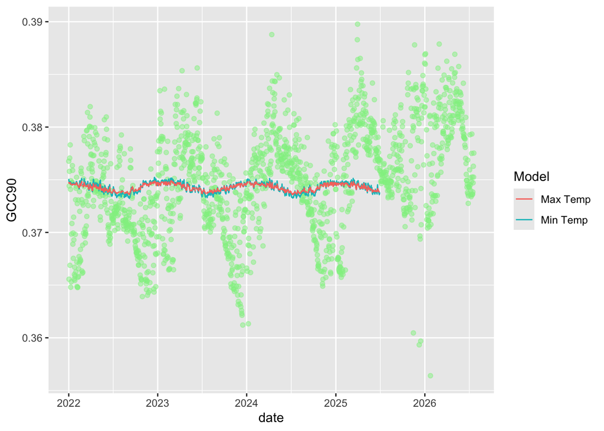

```r
# fit the model to the 'future' dataframe
fut_pred <- fut_pred %>%
  mutate(pred_temp_min = predict.lm(fit_temp_min, tibble(wssTempTripleMinimum)),
        pred_temp_max = predict.lm(fit_temp_max, tibble(wssTempTripleMaximum))) %>%
  mutate(date = as.Date(date))

# visualize fit for both predictions
ggplot(fut_pred) +
  geom_point(aes(x=date, y=gcc_90, col="obs"), col='lightgreen', alpha=0.5) +
  geom_line(aes(x=date, y=pred_temp_min, col="Min Temp")) +
  geom_line(aes(x=date, y=pred_temp_max, col="Max Temp")) +
  labs(col="Model", y="GCC90")
```

Visually, we can see that our models are very similar, and don’t quite capture the highs and lows of GCC_90 (green points). We can apply scores to see how well the models perform below.

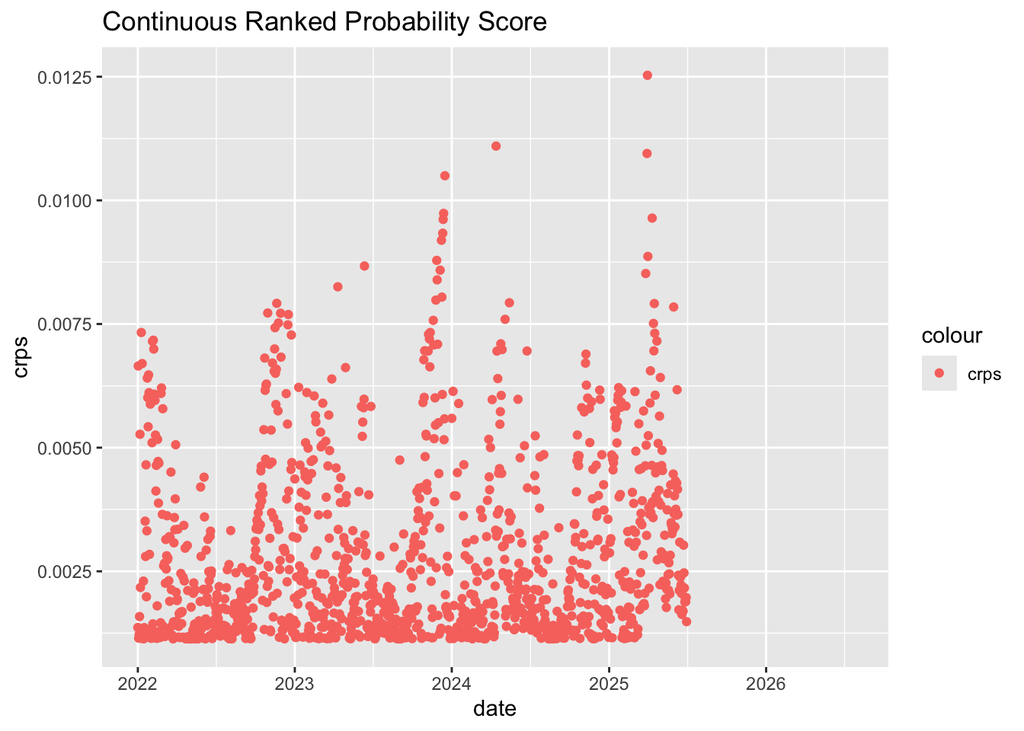

```r
# score forecast
# using continuous Ranked probability Score


# CRPS for normal distribution (most common for linear models)
# If you have prediction standard deviations/errors
calculate_crps_normal <- function(observed, predicted, pred_sd) {
  crps_norm(y = observed, mean = predicted, sd = pred_sd)
}

# CRPS for point forecasts (assuming normal distribution with estimated variance)
calculate_crps_point <- function(observed, predicted) {
  # Estimate residual standard deviation from your model
  residuals <- observed - predicted
  residual_sd <- sd(residuals, na.rm = TRUE)

  # Calculate CRPS assuming normal distribution
  crps_norm(y = observed, mean = predicted, sd = residual_sd)
}

fut_pred$crps = calculate_crps_point(fut_pred$gcc_90,
                                        fut_pred$pred_temp_min)

ggplot(fut_pred) +
  geom_point(aes(x=date, y=crps, col="crps")) + ggtitle("Continuous Ranked Probability Score")
```

In addition to CRPS, we can use the `accuracy()` function on both models to calculate scores, including Mean Error (ME), Root Mean Squared Error (RMSE), Mean Absolute Error (MSE), Mean Percentage Error (MPE), and Mean Absolute Percentage Error (MAPE)

```r
# use forecast package to get accuracy scores
accuracy(fut_pred$pred_temp_min, fut_pred$gcc_90)
```

```
##                     ME        RMSE         MAE         MPE     MAPE
## Test set -0.0001841653 0.004852002 0.003982841 -0.06578803 1.066119
```

```r
accuracy(fut_pred$pred_temp_max, fut_pred$gcc_90)
```

```
##                     ME        RMSE         MAE         MPE     MAPE
## Test set -0.0001742336 0.004847973 0.003983761 -0.06315798 1.066277
```

## Submit to forecasting challenging

You may optionally want to submit your forecast to the NEON challenge to see how well it performs moving forward. See the steps on how to do this at this link: [How to submit a forecast](https://projects.ecoforecast.org/neon4cast-ci/instructions.html).